# PCET pH Swings: Pareto Frontier Shifts

A penalty function is not necessary for the flux because insufficient capture would manifest as negative fluxes. It may still show up in the Pareto frontier, but it can easily be filtered out, unlike the cases with the energy demand.

See the script analyzing the basic conditions for details on its construction.

The inlet term is constant at 0.15 atm and the reference point is 90% reduction in the partial pressure in the lean gas. The calculation is based on mass balance, assuming that the volume adjusted to maintain a total pressure of 1 atm.

Assuming 1 total mole of gas is processed at the reference point: * Inlet: 0.15 mol CO2, 0.85 mol not CO2 * Lean gas: 0.85 mol not CO2, (0.015*0.85)/(1 - 0.015) mol CO2* Enriched gas: 1 - (0.015*0.85)/(1 - 0.015) mol CO2, 0.1% not CO2

The lean gas and enriched gas will change according to the system with a similar mass balance.

Applying the penalty function directly to energy demand

```r
weight.fun = function(pCO2.lean){
  # Ideal
  n.inlet = c(0.15, 0.85)
  n.lean = c(0.85, 0.015*0.85/(1 - 0.015))
  n.enrich = c(0.001*(1 - 0.015*0.85/(1 - 0.015)), 1 - 0.015*0.85/(1 - 0.015))

  E.ideal = sum(n.enrich*log(n.enrich/sum(n.enrich)) +
                  n.lean*log(n.lean/sum(n.lean)) -
                  n.inlet*log(n.inlet/sum(n.inlet)))

  # Actual: separate into 3 cases:
  E.tru = rep(x = 0, times = length(pCO2.lean))
  # Third case: if the lean gas pressure is above 1, i.e. it pressurized
  pos3 = (pCO2.lean >= 0.99)
  # Set the lean gas pressure to 0.999,
  # then multiply the weight by the actual pressure to correct the energy;
  # since the weight is divided by this energy, this means dividing by the pressure
  set.lean = 0.999
  n.enrich.co2 = (set.lean - 0.15)/(1 - set.lean)
  n.lean = n.enrich.co2 + 0.15
  n.enrich.gas = 0.001*n.enrich.co2
  E.tru[pos3] = (- sum(n.inlet*log(n.inlet/sum(n.inlet))) +
    0.85*log(0.85/(n.lean + 0.85)) +
    n.enrich.gas*log(n.enrich.gas/(n.enrich.gas + n.enrich.co2)) +
    n.enrich.co2*log(n.enrich.co2/(n.enrich.gas + n.enrich.co2)) +
    n.lean*log(n.lean/(n.lean + 0.85))) / pCO2.lean[pos3]

  # Second case: if the lean gas pressure is between 0.15 and 1,
  # i.e. the CO2 was moved from the pure gas to the lean gas
  pos2 = (pCO2.lean >= 0.15 & pCO2.lean < 0.99)
  # For the mass balance to work, gas must have moved from the enriched stream to the lean gas
  n.enrich.co2 = (pCO2.lean[pos2] - 0.15)/(1 - pCO2.lean[pos2])
  n.lean = n.enrich.co2 + 0.15
  n.enrich.gas = 0.001*n.enrich.co2
  E.tru[pos2] = - sum(n.inlet*log(n.inlet/sum(n.inlet))) +
    0.85*log(0.85/(n.lean + 0.85)) +
    n.enrich.gas*log(n.enrich.gas/(n.enrich.gas + n.enrich.co2)) +
    n.enrich.co2*log(n.enrich.co2/(n.enrich.gas + n.enrich.co2)) +
    n.lean*log(n.lean/(n.lean + 0.85))

  # First case: if the lean gas pressure is less than 0.15, i.e. some amount of capture happened
  pos1 = (pCO2.lean < 0.15)
  # Mathematically identical to the lean gas case, just adjusting the lean gas and enriched gas mass balance
  n.lean = pCO2.lean[pos1]*0.85/(1 - pCO2.lean[pos1])
  n.enrich.co2 = 0.15 - n.lean
  n.enrich.gas = 0.001*n.enrich.co2

  E.tru[pos1] = - sum(n.inlet*log(n.inlet/sum(n.inlet))) +
    0.85*log(0.85/(n.lean + 0.85)) +
    n.enrich.gas*log(n.enrich.gas/(n.enrich.gas + n.enrich.co2)) +
    n.enrich.co2*log(n.enrich.co2/(n.enrich.gas + n.enrich.co2)) +
    n.lean*log(n.lean/(n.lean + 0.85))

  # Maximum weight
  weight.max = E.ideal/E.tru

  # Logistic function
  L = weight.max - 0.98
  k = 267; x0 = 0.071
  # data.frame(weight.max)
  return(25*L/(1 + exp(-k * (pCO2.lean - x0))) + 1)
}

# Total energy demand - 4-stage process for simplicity
Energy.tot = function(k1, k2, beta1, beta2, A.tot, Na, pCO2.in, pCO2.out){
  # Constants
  z = 2; R = 8.314; T = 298; F = 96485; resolution = 151;
  # pCO2.in = 0.1; pCO2.out = 1
  xA.lim = c(0.025, 0.975)

  # 1 -> 2: Electrochemical oxidation (xA decrease to endpoint), constant DIC
  # Starting solution for initial guess: low P, high xA
  start.soln = data.frame(p.CO2 = pCO2.in, xA = max(xA.lim))
  start.soln$pH = pH.xA.pCO2.A.k.beta.Na(xA = start.soln$xA, P = start.soln$p.CO2,
                                       At = A.tot, k1 = k1, k2 = k2, beta1 = beta1, beta2 = beta2, Na = Na)
  start.soln$DIC = DIC.xA.pCO2.pH.A.k.beta(xA = start.soln$xA, pCO2 = start.soln$p.CO2, pH = start.soln$pH,
                                         A.tot = A.tot, k1 = k1, k2 = k2, beta1 = beta1, beta2 = beta2)
  # Anode progress
  E.anode = data.frame(DIC = start.soln$DIC, xA = seq(from = start.soln$xA[1], to = min(xA.lim), length.out = resolution))
  # Loop to solve the ieration function
  loop = pH.it.guess.DIC.At.k.beta(pH.guess = start.soln$pH[1], xA.next = E.anode$xA[1], DIC = E.anode$DIC[1],
                                       A.tot = A.tot, k1 = k1, k2 = k2, beta1 = beta1, beta2 = beta2, Na = Na)
  for(i in 2:length(E.anode$DIC)){
    loop = c(loop, pH.it.guess.DIC.At.k.beta(pH.guess = loop[i-1], xA.next = E.anode$xA[i], DIC = E.anode$DIC[i],
                                         A.tot = A.tot, k1 = k1, k2 = k2, beta1 = beta1, beta2 = beta2, Na = Na))
  }
  # Some iterations don't converge completely, leading to single points that deviated from the rest of the curve. This is characterized by a single point that is a local maxima or minimum. Endpoints are asusmed to be good
  loop.check.left = loop[1:(resolution-2)] - loop[2:(resolution-1)]
  loop.check.right = loop[2:(resolution-1)] - loop[3:(resolution)]
  # If the signs are different, then it is a local shift
  loop.pos = c(TRUE, (sign(loop.check.left) == sign(loop.check.right)), TRUE)
  for(pos in which(loop.pos == FALSE)){ # Take the average
    loop[pos] = (loop[pos-1] + loop[pos+1])/2
  }
  E.anode$pH = loop;
  # Loop pCO2 calculation as well, since the pCO2 function relies on the previous point
  loop = pCO2.xA.pH.A.k.beta.Na(xA = E.anode$xA[1], pH = E.anode$pH[1],
                                At = A.tot, k1 = k1, k2 = k2, beta1 = beta1, beta2 = beta2, Na = Na, pCO2.prev = start.soln$p.CO2)
  for(i in 2:length(E.anode$DIC)){
    loop[i] = pCO2.xA.pH.A.k.beta.Na(xA = E.anode$xA[i], pH = E.anode$pH[i],
                                  At = A.tot, k1 = k1, k2 = k2, beta1 = beta1, beta2 = beta2, Na = Na, pCO2.prev = loop[i-1])
  }
  E.anode$p.CO2 = loop
  E.anode$q = abs(E.anode$xA - E.anode$xA[1])*A.tot*z*F # Coulombs

  # 3 -> 4: Electrochemical reduction (xA increase to endpoint), constant DIC
  # Starting solution for initial guess: high P, low xA
  stop.soln = data.frame(p.CO2 = pCO2.out, xA = min(xA.lim))
  stop.soln$pH = pH.xA.pCO2.A.k.beta.Na(xA = stop.soln$xA, P = stop.soln$p.CO2,
                                       At = A.tot, k1 = k1, k2 = k2, beta1 = beta1, beta2 = beta2, Na = Na)
  stop.soln$DIC = DIC.xA.pCO2.pH.A.k.beta(xA = stop.soln$xA, pCO2 = stop.soln$p.CO2, pH = stop.soln$pH,
                                         A.tot = A.tot, k1 = k1, k2 = k2, beta1 = beta1, beta2 = beta2)
  # Cathode progress
  E.cathode = data.frame(DIC = stop.soln$DIC[1], xA = seq(from = stop.soln$xA[1], to = max(xA.lim), length.out = resolution))
  # Loop to solve the ieration function
  loop = pH.it.guess.DIC.At.k.beta(pH.guess = stop.soln$pH[1], xA.next = E.cathode$xA[1], DIC = E.cathode$DIC[1],
                                       A.tot = A.tot, k1 = k1, k2 = k2, beta1 = beta1, beta2 = beta2, Na = Na)
  for(i in 2:length(E.cathode$DIC)){
    loop = c(loop, pH.it.guess.DIC.At.k.beta(pH.guess = loop[i-1], xA.next = E.cathode$xA[i], DIC = E.cathode$DIC[i],
                                         A.tot = A.tot, k1 = k1, k2 = k2, beta1 = beta1, beta2 = beta2, Na = Na))
  }
  # Some iterations don't converge completely, leading to single points that deviated from the rest of the curve. This is characterized by a single point that is a local maxima or minimum. Endpoints are asusmed to be good
  loop.check.left = loop[1:(resolution-2)] - loop[2:(resolution-1)]
  loop.check.right = loop[2:(resolution-1)] - loop[3:(resolution)]
  # If the signs are different, then it is a local shift
  loop.pos = c(TRUE, (sign(loop.check.left) == sign(loop.check.right)), TRUE)
  for(pos in which(loop.pos == FALSE)){ # Take the average
    loop[pos] = (loop[pos-1] + loop[pos+1])/2
  }
  E.cathode$pH = loop;
  # Loop pCO2 calculation as well, since the pCO2 function relies on the previous point
  loop = pCO2.xA.pH.A.k.beta.Na(xA = E.cathode$xA[1], pH = E.cathode$pH[1],
                                At = A.tot, k1 = k1, k2 = k2, beta1 = beta1, beta2 = beta2, Na = Na, pCO2.prev = stop.soln$p.CO2)
  for(i in 2:length(E.cathode$DIC)){
    loop[i] = pCO2.xA.pH.A.k.beta.Na(xA = E.cathode$xA[i], pH = E.cathode$pH[i],
                                  At = A.tot, k1 = k1, k2 = k2, beta1 = beta1, beta2 = beta2, Na = Na, pCO2.prev = loop[i-1])
  }
  E.cathode$p.CO2 = loop
  E.cathode$q = abs(E.cathode$xA - E.cathode$xA[1])*A.tot*z*F # Coulombs

  # Equilibrium potential: Deviation from standard reduction potential
  E.anode$H = 10^-E.anode$pH
  E.anode$E = R*T/(z*F) * log( (1 - E.anode$xA)/E.anode$xA *
                                   ((1 + beta1*E.anode$p.CO2 + beta2*E.anode$p.CO2^2)*k1*k2 + k1*E.anode$H + E.anode$H^2)/(k1*k2))
  E.cathode$H = 10^-E.cathode$pH
  E.cathode$E = R*T/(z*F) * log( (1 - E.cathode$xA)/E.cathode$xA *
                                   ((1 + beta1*E.cathode$p.CO2 + beta2*E.cathode$p.CO2^2)*k1*k2 + k1*E.cathode$H + E.cathode$H^2)/(k1*k2))

  # Total energy
  E.cell = data.frame(q = E.anode$q, V = E.anode$E - E.cathode$E)
  # Only the positive energy demand
  E.cell = filter(E.cell, V > 0)
  len = length(E.cell$q)
  if(len == 0){
    E.cell = data.frame(q = rep(x = 0, times = 10), V = rep(x = 0, times = 10))
    len = 10
  }
  # E.anode$typ = "anode"; E.cathode$typ = "cathode"
  Energy.tot.sep = sum(0.5*(E.cell$V[2:len] + E.cell$V[1:(len-1)])*(E.cell$q[2:len] - E.cell$q[1:(len-1)]))

  ## Adjust the total energy by multiplying by the penalty function
  # Calculate the lean gas pressure
  # k1, k2, beta1, beta2, A.tot, Na, pCO2.in, pCO2.out
  p.lean = pCO2.lean(Na = Na, A = A.tot, beta1 = beta1, beta2 = beta2, k1 = k1, k2 = k2, pCO2.out = pCO2.out)
  penalty = weight.fun(pCO2.lean = p.lean)

  # Normalize by the total amount of carbon moved, i.e. units of kJ/mol
  DIC.capture = DIC.diff(Na = Na, A = A.tot, beta1 = beta1, beta2 = beta2, k1 = k1, k2 = k2, pCO2.in = pCO2.in, pCO2.out = pCO2.out)
  return(Energy.tot.sep*penalty/DIC.capture*1e-3)
}
```

```r
# These equations are based on the framework for determining the CO2 flux as presented in Wilcox 2012.
Enhance.factor = function(pH, pCO2.in, A, k1, k2, beta1, beta2, pCO2){
  # Constants: general
  kw = 1e-14 # M^2
  kH = 3.4e-2; # M/atm
  z = 1 # OH- + CO2 = HCO3-
  # Constants: from Wilcox 2012
  Dco2 = 0.5e-5 # cm2/s, assume slowest due to high ionic strength
  kL = 0.1 # Assume fast mass transfer of typical range
  # Constants: average of Pocker 1997, Zeman 2007, Stolaroff 2008, Wilcox 2012
  k.rate = (6.03e3 + 6.745e3 + 8.5e3 + 12.1e3)/4
  # Constants: Lvov2012
  Doh = 5.2e-5 # cm2/s

  # Base concentration = OH + HQ- + 2Q--
  H = 10^-pH
  OH = kw/H
  base = OH + A*(2*k1*k2 + H*k1) / (H^2 + H*k1 + k1*k2*(1 + beta1*pCO2 + beta2*pCO2^2))

  # Interface CO2 concentration - assume 90% capture from the inlet
  CO2.int = pCO2.in*kH

  # Hatta number: reaction rate / mass transfer rate
  Ha = sqrt(Dco2*base*k.rate)/kL
  # Instantaneous enhancement factor
  Ei = 1 + Doh*base / (z*Dco2*CO2.int)

  # return(c(Ei, Ha / tanh(Ha), Ha))
  # Check the extreme cases for E to simplify the equations
  if(Ha > 10*Ei){ # Instantaneous
    E = Ei
  } else if(Ha < Ei/2){ # Pseudo-1st order
    E = Ha / tanh(Ha)
  } else if(Ha > 3){ # 1st order
    E = Ha
  } else{ # No simplification - Solve the root that is less than Ei, as Ei is the upper bound
    x.guess = c(0.9, 0.95)*Ei
    for(i in 1:5){ # Newton's method
      y.guess = (Ha*(Ei - x.guess) / (Ei - 1)) / tanh(Ha*(Ei - x.guess) / (Ei - 1)) - x.guess
      slp.fit = (y.guess[1] - y.guess[2]) / (x.guess[1] - x.guess[2])
      E.guess = -y.guess[1]/slp.fit + x.guess[1]
      x.guess = c(0.975, 1.025)*E.guess
    }
    E = E.guess
  }
  #### Need to include order of magnitude for reaction rate with sorbent - use acid anhydride formation rate constants as estimates?
  return(E)
}

# Calculate the average kinetic driving force over the course of absorption (stage 4 -> 1)
kinetic.force = function(k1, k2, beta1, beta2, A.tot, Na, pCO2.in, pCO2.out){
  # Constants
  xA.lim = c(0.025, 0.975)
  kH = 3.4e-2; # M/atm
  # Calculate the pCO2 of the fully reduced species prior to equilibration with the gas
  out.pCO2 = pCO2.lean(Na = Na, A = A.tot, beta1 = beta1, beta2 = beta2, k1 = k1, k2 = k2, pCO2.out = pCO2.out)
  # If the minimum outlet pCO2 is greater than the target capture:
  # if(out.pCO2 > 0.1*pCO2.in | is.na(out.pCO2)){
  if(is.na(out.pCO2)){
    return(0)
  } else{
    # Calculate the pH at the start of desorption
    soln41 = data.frame(xA = max(xA.lim), p.CO2 = out.pCO2)
    # Solve pH with multiple cores
    soln41$pH = pH.xA.pCO2.A.k.beta.Na(xA = soln41$xA, P = soln41$p.CO2,
                         At = A.tot, k1 = k1, k2 = k2, beta1 = beta1, beta2 = beta2, Na = Na)
    soln41$E = Enhance.factor(pH = soln41$pH, pCO2.in = pCO2.in, A = A.tot, k1 = k1, k2 = k2, beta1 = beta1, beta2 = beta2, pCO2 = soln41$p.CO2)

    # Calculate the concentration difference between the interface and the bulk. Assuming 90% capture
    soln41$delC = (pCO2.in - out.pCO2)*kH
    # Flux: delC * kL * E, assume kL = 0.1 cm/s
    # Unit conversion: L to cm3, cm2 to m2
    flux = soln41$delC*soln41$E*0.1 * (1/1e3) * (100^2)
    # return(soln41)
    return(signif(flux, 5)) # Highest driving force at outlet
    # return(soln41)
  }
}
```

To work with GPareto, the two objective functions need to combined, and the input should be a matrix, not a dataframe. I account for this with a wrapper function to simplify the process.

```r
PCET.obj.flu.base = function(inputs){
  # Inputs is a matrix where each row is an instance and each column is a specific variable:
  # From left to right, the columns are:
  # pka1, err.pka2, log10(A.tot), Na/A.tot
  # For the functions, the variables should be:
  # k1, k2, A.tot, Na
  # The use of log units and ratios helps alleviate resolution issues associated with spanning multiple orders of magnitude
  # The use of the error of pKa2 removes the correlation between the two variables

  # Storing the proper information.
  if(is.matrix(inputs)){
    dat = data.frame(k1 = 10^-inputs[,1],
                     k2 = 10^-(inputs[,1] + inputs[,2]),
                     A.tot = 10^inputs[,3],
                     Na = 10^inputs[,4]*10^inputs[,3])
  } else{
    # The optimization function sometimes stores as a vector instead of as a matrix if it is just a single point
    dat = data.frame(k1 = 10^-inputs[1],
                     k2 = 10^-(inputs[1] + inputs[2]),
                     A.tot = 10^inputs[3],
                     Na = 10^inputs[4]*10^inputs[3])
  }
  # The following conditions are assumed for PCET from flue gas
  beta1 = 0; beta2 = 0;
  pCO2.in = 0.15; pCO2.out = 1;

  # The functions require substantial computation, so each row has to be processed independently
  energy = c(); flux = c()
  for(i in 1:nrow(dat)){
    energy[i] = Energy.tot(k1 = dat$k1[i], k2 = dat$k2[i],
                           beta1 = 0, beta2 = 0,
                           A.tot = dat$A.tot[i], Na = dat$Na[i],
                           pCO2.in = 0.15, pCO2.out = 1)
    flux[i] = kinetic.force(k1 = dat$k1[i], k2 = dat$k2[i],
                            beta1 = 0, beta2 = 0,
                            A.tot = dat$A.tot[i], Na = dat$Na[i],
                            pCO2.in = 0.15, pCO2.out = 1)
  }
  # Obtain the negative of the flux so it is a minimization function for the optimization search
  return(c(log10(energy), -flux))
}
```

# Pareto frontier search: Starting Design

Use the starting dataset for the +base condition after refinement to points that can capture some CO2.

```r
# Re-save in this folder
GPar.all = read.csv('../Ex_PCET_Basic/GPar_all_data.csv')
GPar.fnt = read.csv('../Ex_PCET_Basic/GPar_fnt_data.csv')

# Flux needs to be flipped
GPar.all$Flux.mol.m2s = -GPar.all$Flux.mol.m2s
GPar.fnt$Flux.mol.m2s = -GPar.fnt$Flux.mol.m2s
# Energy in log units
GPar.all$Energy.kJ.mol = log10(GPar.all$Energy.kJ.mol)
GPar.fnt$Energy.kJ.mol = log10(GPar.fnt$Energy.kJ.mol)

write.csv(GPar.all, 'GPar_all_base.csv')
write.csv(GPar.fnt, 'GPar_fnt_base.csv')
```

# Pareto frontier search: concentration

Using the same objective function but modifying the bounds of the quinone concentration from high to low: 7, 5, 3, 1, 0.5 (logA = 0.85, 0.7, 0.5, 0, -0.3)

Start the search with the high value constraint, then filter out the points that are too high for the next highest and proceed downward by filling in the same number of points that were removed. Doing the optimization in this way guarantees that any observed shifts in the Pareto front are from the constriction of the input range and not from additional sampling resolution.

```r
# Initial ranges
pka1.rng = c(2, 13.5); pka2.rng = c(0, 5.5)
logA.rng = c(-2, 0.85); Na.A.rng = c(-7, 0.7)

# Since the concentration is lower, can use the data from the previous Pareto front search, but
# filtering out points and then randomly sampling up to the required number
design.start = read.csv(file = 'GPar_all_base.csv')
# Set the budget
Pareto.budget = 150

# Separate into different matrices
result.start = design.start[,c('Energy.kJ.mol', 'Flux.mol.m2s')]
design.start = design.start[,c('pka1', 'pka2', 'logA', 'Na.A')]

res = easyGParetoptim(fn = PCET.obj.flu.base, budget = Pareto.budget,
                      lower = c(min(pka1.rng), min(pka2.rng), min(logA.rng), min(Na.A.rng)),
                      upper = c(max(pka1.rng), max(pka2.rng), max(logA.rng), max(Na.A.rng)),
                      par = as.matrix(design.start), value = as.matrix(result.start), ncores = 2)
```

```
----------------------------
Starting optimization with :
 The criterion SMS
 The solver pso
----------------------------
Ite / Crit / New x / New y
No refPoint provided,  2.65 0.995 used
1   /   -1.68   /   11.1    5.5 -1.28   -7  /   1.45    -0.00566
2   /   -1.54   /   9.97    5.5 -2  -7  /   2.33    0.00993
3   /   -1.39   /   11.8    5.5 -1.17   -5.87   /   1.49    -0.00592
4   /   -1.42   /   11.8    4.13    -1.36   -7  /   1.44    -0.00537
5   /   -1.26   /   13.5    3.93    -0.498  -7  /   1.59    -0.0094
6   /   -1.25   /   11.2    3.18    -2  -7  /   2.33    0.00993
7   /   -1.22   /   6.46    4.37    -1.28   -7  /   1.16    -0.00555
8   /   -1.19   /   13.5    5.5 -0.242  -5.42   /   1.6 -0.0126
```

[output cut: 144 more lines]

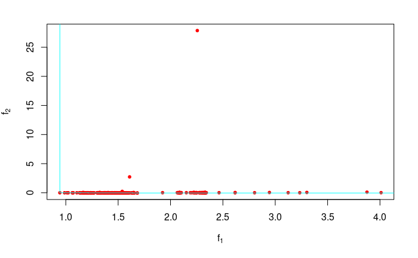

```r
plotGPareto(res)
```

```r
# Format into dataframe for easier plotting
GPar.front = data.frame(pka1 = res$par[,1], pka2 = res$par[,2], logA = res$par[,3], Na.A = res$par[,4],
                        Energy.kJ.mol = res$value[,1], Flux.mol.m2s = res$value[,2])
GPar.all =  data.frame(pka1 = res$history$X[,1], pka2 = res$history$X[,2], logA = res$history$X[,3],
                       Na.A = res$history$X[,4],
                       Energy.kJ.mol = res$history$y[,1], Flux.mol.m2s = res$history$y[,2])
rm(res)
write.csv(GPar.front, file = 'GPar_fnt_Qhst.csv')
write.csv(GPar.all, file = 'GPar_all_Qhst.csv')
```

```r
# Initial ranges
pka1.rng = c(2, 13.5); pka2.rng = c(0, 5.5)
logA.rng = c(-2, 0.7); Na.A.rng = c(-7, 0.7)

# Since the concentration is lower, can use the data from the previous Pareto front search, but
# filtering out points and then randomly sampling up to the required number
design.start = read.csv(file = 'GPar_all_Qhst.csv')
# Set the budget as the number of points that will be filtered
Pareto.budget = nrow(design.start) - nrow(filter(design.start, logA < max(logA.rng)))
design.start = filter(design.start, logA < max(logA.rng))

# Separate into different matrices
result.start = design.start[,c('Energy.kJ.mol', 'Flux.mol.m2s')]
design.start = design.start[,c('pka1', 'pka2', 'logA', 'Na.A')]

res = easyGParetoptim(fn = PCET.obj.flu.base, budget = Pareto.budget,
                      lower = c(min(pka1.rng), min(pka2.rng), min(logA.rng), min(Na.A.rng)),
                      upper = c(max(pka1.rng), max(pka2.rng), max(logA.rng), max(Na.A.rng)),
                      par = as.matrix(design.start), value = as.matrix(result.start), ncores = 2)
```

```
----------------------------
Starting optimization with :
 The criterion SMS
 The solver pso
----------------------------
Ite / Crit / New x / New y
No refPoint provided,  2.65 0.995 used
1   /   -0.437  /   13.5    5.5 -0.915  -4.2    /   1.54    -0.00643
2   /   -0.422  /   12.1    2.59    -1.4    -6.09   /   1.42    -0.00521
3   /   -0.409  /   13.5    3.82    -0.905  -5.18   /   1.55    -0.00648
```

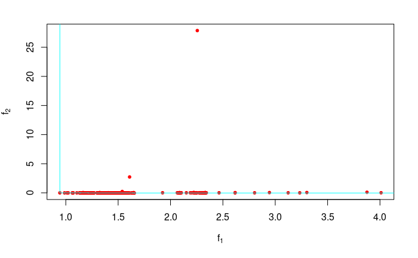

```r
plotGPareto(res)
```

```r
# Format into dataframe for easier plotting
GPar.front = data.frame(pka1 = res$par[,1], pka2 = res$par[,2], logA = res$par[,3], Na.A = res$par[,4],
                        Energy.kJ.mol = res$value[,1], Flux.mol.m2s = res$value[,2])
GPar.all =  data.frame(pka1 = res$history$X[,1], pka2 = res$history$X[,2], logA = res$history$X[,3],
                       Na.A = res$history$X[,4],
                       Energy.kJ.mol = res$history$y[,1], Flux.mol.m2s = res$history$y[,2])
rm(res)
write.csv(GPar.front, file = 'GPar_fnt_Qhig.csv')
write.csv(GPar.all, file = 'GPar_all_Qhig.csv')
```

```r
# Initial ranges
pka1.rng = c(2, 13.5); pka2.rng = c(0, 5.5)
logA.rng = c(-2, 0.5); Na.A.rng = c(-7, 0.7)

# Since the concentration is lower, can use the data from the previous Pareto front search, but
# filtering out points and then randomly sampling up to the required number
design.start = read.csv(file = 'GPar_all_Qhig.csv')
# Set the budget as the number of points that will be filtered
Pareto.budget = nrow(design.start) - nrow(filter(design.start, logA < max(logA.rng)))
design.start = filter(design.start, logA < max(logA.rng))

# Separate into different matrices
result.start = design.start[,c('Energy.kJ.mol', 'Flux.mol.m2s')]
design.start = design.start[,c('pka1', 'pka2', 'logA', 'Na.A')]

res = easyGParetoptim(fn = PCET.obj.flu.base, budget = Pareto.budget,
                      lower = c(min(pka1.rng), min(pka2.rng), min(logA.rng), min(Na.A.rng)),
                      upper = c(max(pka1.rng), max(pka2.rng), max(logA.rng), max(Na.A.rng)),
                      par = as.matrix(design.start), value = as.matrix(result.start), ncores = 2)
```

```
----------------------------
Starting optimization with :
 The criterion SMS
 The solver pso
----------------------------
Ite / Crit / New x / New y
No refPoint provided,  2.65 0.995 used
1   /   -0.00655    /   12.9    5.5 0.5 -7  /   1.64    -0.0311
refPoint changed,  2.64 0.995 used
2   /   -0.00467    /   13.5    5.5 0.5 -7  /   1.65    -0.0309
3   /   -0.00435    /   13.5    5.5 0.5 -2.14   /   1.65    -0.0308
4   /   -0.00379    /   11.2    5.5 0.5 -3.74   /   1.58    -0.031
5   /   -0.00385    /   12  5.5 0.5 -3.75   /   1.61    -0.0311
refPoint changed,  2.61 0.995 used
6   /   -0.00342    /   11.6    5.5 0.5 -3.14   /   1.6 -0.0311
7   /   -0.00333    /   12.7    5.5 0.5 -2.84   /   1.63    -0.0311
8   /   -0.00323    /   9.64    5.5 0.5 -5.46   /   1.52    -0.0279
9   /   -0.00288    /   13.5    5.5 0.5 -2.83   /   1.65    -0.0309
```

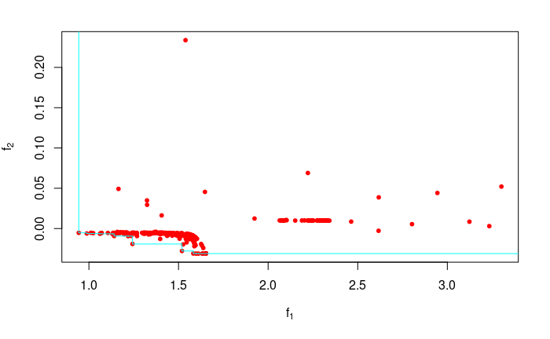

```r
plotGPareto(res)
```

```r
# Format into dataframe for easier plotting
GPar.front = data.frame(pka1 = res$par[,1], pka2 = res$par[,2], logA = res$par[,3], Na.A = res$par[,4],
                        Energy.kJ.mol = res$value[,1], Flux.mol.m2s = res$value[,2])
GPar.all =  data.frame(pka1 = res$history$X[,1], pka2 = res$history$X[,2], logA = res$history$X[,3],
                       Na.A = res$history$X[,4],
                       Energy.kJ.mol = res$history$y[,1], Flux.mol.m2s = res$history$y[,2])
rm(res)
write.csv(GPar.front, file = 'GPar_fnt_Qmid.csv')
write.csv(GPar.all, file = 'GPar_all_Qmid.csv')
```

```r
# Initial ranges
pka1.rng = c(2, 13.5); pka2.rng = c(0, 5.5)
logA.rng = c(-2, 0); Na.A.rng = c(-7, 0.7)

# Since the concentration is lower, can use the data from the previous Pareto front search, but
# filtering out points and then randomly sampling up to the required number
design.start = read.csv(file = 'GPar_all_Qmid.csv')
# Shorten the budget by the number of points that will be removed
Pareto.budget = nrow(design.start) - nrow(filter(design.start, logA < max(logA.rng)))
design.start = filter(design.start, logA < max(logA.rng))

# Separate into different matrices
result.start = design.start[,c('Energy.kJ.mol', 'Flux.mol.m2s')]
design.start = design.start[,c('pka1', 'pka2', 'logA', 'Na.A')]

res = easyGParetoptim(fn = PCET.obj.flu.base, budget = Pareto.budget,
                      lower = c(min(pka1.rng), min(pka2.rng), min(logA.rng), min(Na.A.rng)),
                      upper = c(max(pka1.rng), max(pka2.rng), max(logA.rng), max(Na.A.rng)),
                      par = as.matrix(design.start), value = as.matrix(result.start), ncores = 2)
```

```
----------------------------
Starting optimization with :
 The criterion SMS
 The solver pso
----------------------------
Ite / Crit / New x / New y
No refPoint provided,  2.55 0.995 used
1   /   -0.18   /   2   5.5 0   0.7 /   1.52    0.56
2   /   -0.0664 /   2   5.5 0   -3.34   /   5.81    -0.000519
3   /   -0.0106 /   13.5    0   0   -7  /   1.59    -0.0109
4   /   -0.00925    /   13.5    2.7 0   -7  /   1.62    -0.0168
5   /   -0.00906    /   12  0.996   0   -7  /   1.54    -0.0126
6   /   -0.00879    /   11.9    4.77    0   -7  /   1.58    -0.0174
refPoint changed,  2.58 0.995 used
7   /   -0.00874    /   12.1    5.5 0   -5.99   /   1.58    -0.0174
refPoint changed,  2.58 0.995 used
8   /   -0.00673    /   11  1.04    -0.514  -7  /   1.45    -0.00773
9   /   -0.00809    /   13.5    0   0   -5.42   /   1.59    -0.0109
10  /   -0.00802    /   12.8    4.7 0   -6.04   /   1.6 -0.0173
11  /   -0.00791    /   13.5    4.85    0   -7  /   1.62    -0.0169
12  /   -0.00762    /   13.5    1.5 0   -7  /   1.62    -0.0158
13  /   -0.00734    /   11.7    5.5 0   -7  /   1.57    -0.0174
refPoint changed,  2.57 0.995 used
14  /   -0.00714    /   13.5    4.24    0   -5.62   /   1.62    -0.0169
15  /   -0.00677    /   12.2    4.08    0   -5.82   /   1.59    -0.0173
16  /   -0.00623    /   13.5    5.5 0   -6.29   /   1.62    -0.0169
17  /   -0.00666    /   12  4.91    0   -5.49   /   1.58    -0.0174
18  /   -0.00599    /   12.7    5.5 0   -7  /   1.6 -0.0173
19  /   -0.0255 /   7.59    2.76    -0.985  0.432   /   1.03    -0.00587
20  /   -0.00631    /   12.4    4   0   -7  /   1.59    -0.0173
21  /   -0.00627    /   12.7    3.38    -3.23e-10   -6.17   /   1.6 -0.0172
22  /   -0.00593    /   13.5    2.48    0   -6.04   /   1.62    -0.0168
23  /   -0.0152 /   6.02    4.82    -1.14   -4.25   /   1.13    -0.00575
```

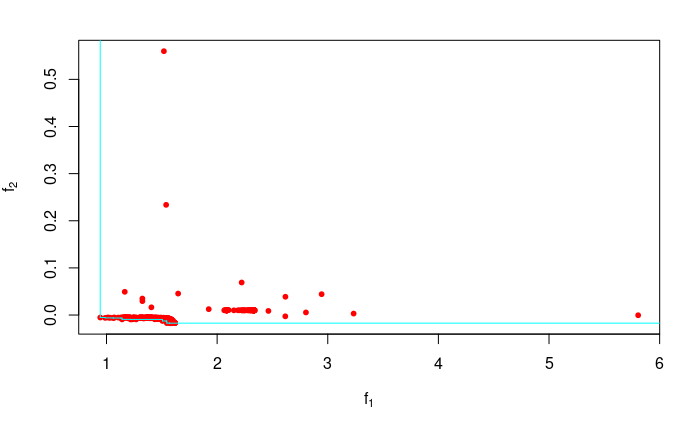

```r
plotGPareto(res)
```

```r
# Format into dataframe for easier plotting
GPar.front = data.frame(pka1 = res$par[,1], pka2 = res$par[,2], logA = res$par[,3], Na.A = res$par[,4],
                        Energy.kJ.mol = res$value[,1], Flux.mol.m2s = res$value[,2])
GPar.all =  data.frame(pka1 = res$history$X[,1], pka2 = res$history$X[,2], logA = res$history$X[,3],
                       Na.A = res$history$X[,4],
                       Energy.kJ.mol = res$history$y[,1], Flux.mol.m2s = res$history$y[,2])
rm(res)
write.csv(GPar.front, file = 'GPar_fnt_Qlow.csv')
write.csv(GPar.all, file = 'GPar_all_Qlow.csv')
```

```r
# Initial ranges
pka1.rng = c(2, 13.5); pka2.rng = c(0, 5.5)
logA.rng = c(-2, -0.3); Na.A.rng = c(-7, 0.7)

# Since the concentration is lower, can use the data from the previous Pareto front search, but
# filtering out points and then randomly sampling up to the required number
design.start = read.csv(file = 'GPar_all_Qlow.csv')
# Shorten the budget by the number of points that will be removed
Pareto.budget = nrow(design.start) - nrow(filter(design.start, logA < max(logA.rng)))
design.start = filter(design.start, logA < max(logA.rng))

# Separate into different matrices
result.start = design.start[,c('Energy.kJ.mol', 'Flux.mol.m2s')]
design.start = design.start[,c('pka1', 'pka2', 'logA', 'Na.A')]

res = easyGParetoptim(fn = PCET.obj.flu.base, budget = Pareto.budget,
                      lower = c(min(pka1.rng), min(pka2.rng), min(logA.rng), min(Na.A.rng)),
                      upper = c(max(pka1.rng), max(pka2.rng), max(logA.rng), max(Na.A.rng)),
                      par = as.matrix(design.start), value = as.matrix(result.start), ncores = 2)
```

```
----------------------------
Starting optimization with :
 The criterion SMS
 The solver pso
----------------------------
Ite / Crit / New x / New y
No refPoint provided,  2.58 0.995 used
1   /   -0.0125 /   13.5    5.5 -0.3    -5.52   /   1.6 -0.0118
refPoint changed,  2.6 0.995 used
2   /   -0.0122 /   11.1    5.5 -0.3    -7  /   1.53    -0.0123
refPoint changed,  2.53 0.995 used
3   /   -0.0827 /   2   5.5 -0.3    0.7 /   1.5 0.217
4   /   -0.00608    /   12.1    4.43    -0.3    -7  /   1.57    -0.0123
5   /   -0.00597    /   12.2    2.29    -0.3    -7  /   1.57    -0.0114
6   /   -0.00501    /   13.5    2.75    -0.3    -7  /   1.6 -0.0118
```

[output cut: 31 more lines]

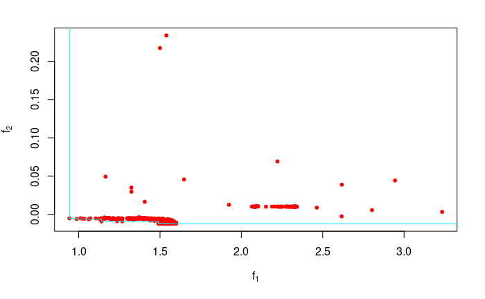

```r
plotGPareto(res)
```

```r
# Format into dataframe for easier plotting
GPar.front = data.frame(pka1 = res$par[,1], pka2 = res$par[,2], logA = res$par[,3], Na.A = res$par[,4],
                        Energy.kJ.mol = res$value[,1], Flux.mol.m2s = res$value[,2])
GPar.all =  data.frame(pka1 = res$history$X[,1], pka2 = res$history$X[,2], logA = res$history$X[,3],
                       Na.A = res$history$X[,4],
                       Energy.kJ.mol = res$history$y[,1], Flux.mol.m2s = res$history$y[,2])
rm(res)
write.csv(GPar.front, file = 'GPar_fnt_Qlst.csv')
write.csv(GPar.all, file = 'GPar_all_Qlst.csv')
```

# Pareto frontier search: pKa difference

```r
# Initial ranges
pka1.rng = c(2, 13.5); pka2.rng = c(0, 9)
logA.rng = c(-2, 0.5); Na.A.rng = c(-7, 0.7)

# Since the concentration is lower, can use the data from the previous Pareto front search, but
# filtering out points and then randomly sampling up to the required number
design.start = read.csv(file = 'GPar_all_base.csv')
# Set the budget
Pareto.budget = 150

# Separate into different matrices
result.start = design.start[,c('Energy.kJ.mol', 'Flux.mol.m2s')]
design.start = design.start[,c('pka1', 'pka2', 'logA', 'Na.A')]

res = easyGParetoptim(fn = PCET.obj.flu.base, budget = Pareto.budget,
                      lower = c(min(pka1.rng), min(pka2.rng), min(logA.rng), min(Na.A.rng)),
                      upper = c(max(pka1.rng), max(pka2.rng), max(logA.rng), max(Na.A.rng)),
                      par = as.matrix(design.start), value = as.matrix(result.start), ncores = 2)
```

```
----------------------------
Starting optimization with :
 The criterion SMS
 The solver pso
----------------------------
Ite / Crit / New x / New y
No refPoint provided,  2.65 0.995 used
1   /   -3.19   /   13.5    9   -1.12   -7  /   1.51    -0.0057
2   /   -2.85   /   13.5    9   -2  -4.18   /   2.33    0.00993
3   /   -2.1    /   11.7    9   -2  -7  /   2.33    0.00993
4   /   -1.9    /   13.5    9   -2  -1.04   /   2.3 0.00991
5   /   -1.54   /   13.5    7.72    -2  -6.17   /   2.33    0.00993
6   /   -1.31   /   11.3    9   -2  -3.02   /   2.33    0.00993
7   /   -1.15   /   11.1    6.55    -1.55   -7  /   1.39    -0.00513
8   /   -1.27   /   10.1    7.25    -2  -7  /   2.33    0.00993
```

[output cut: 143 more lines]

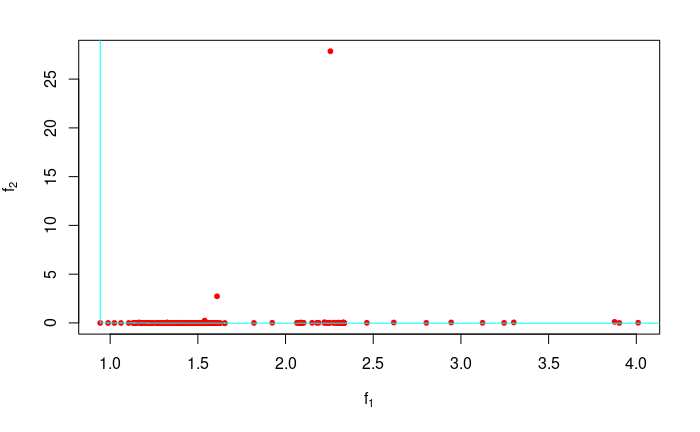

```r
plotGPareto(res)
```

```r
# Format into dataframe for easier plotting
GPar.front = data.frame(pka1 = res$par[,1], pka2 = res$par[,2], logA = res$par[,3], Na.A = res$par[,4],
                        Energy.kJ.mol = res$value[,1], Flux.mol.m2s = res$value[,2])
GPar.all =  data.frame(pka1 = res$history$X[,1], pka2 = res$history$X[,2], logA = res$history$X[,3],
                       Na.A = res$history$X[,4],
                       Energy.kJ.mol = res$history$y[,1], Flux.mol.m2s = res$history$y[,2])
rm(res)
write.csv(GPar.front, file = 'GPar_fnt_pkaH.csv')
write.csv(GPar.all, file = 'GPar_all_pkaH.csv')
```

```r
# Initial ranges
pka1.rng = c(2, 13.5); pka2.rng = c(0, 7.25)
logA.rng = c(-2, 0.5); Na.A.rng = c(-7, 0.7)

# Since the concentration is lower, can use the data from the previous Pareto front search, but
# filtering out points and then randomly sampling up to the required number
design.start = read.csv(file = 'GPar_all_pkaH.csv')
# Set the budget as the number of points that will be filtered
Pareto.budget = nrow(design.start) - nrow(filter(design.start, pka2 < max(pka2.rng)))
design.start = filter(design.start, pka2 < max(pka2.rng))

# Separate into different matrices
result.start = design.start[,c('Energy.kJ.mol', 'Flux.mol.m2s')]
design.start = design.start[,c('pka1', 'pka2', 'logA', 'Na.A')]

res = easyGParetoptim(fn = PCET.obj.flu.base, budget = Pareto.budget,
                      lower = c(min(pka1.rng), min(pka2.rng), min(logA.rng), min(Na.A.rng)),
                      upper = c(max(pka1.rng), max(pka2.rng), max(logA.rng), max(Na.A.rng)),
                      par = as.matrix(design.start), value = as.matrix(result.start), ncores = 2)
```

```
----------------------------
Starting optimization with :
 The criterion SMS
 The solver pso
----------------------------
Ite / Crit / New x / New y
No refPoint provided,  2.65 0.995 used
1   /   -1.41   /   13.5    7.25    -2  -7  /   2.33    0.00993
2   /   -1.23   /   10.8    7.25    -1.71   -4.41   /   1.44    -0.00502
3   /   -1.32   /   13.5    7.25    -2  -2.92   /   2.33    0.00993
4   /   -1.13   /   13.5    7.25    -2  0.7 /   2.09    0.00993
5   /   -0.895  /   12.2    7.25    -1.66   -5.4    /   1.4 -0.00509
6   /   -0.867  /   11.3    7.25    -0.288  -7  /   1.54    -0.0125
7   /   -0.87   /   5.98    7.25    -2  -7  /   2.28    0.01
8   /   -1  /   11.6    7.25    -1.71   -1.8    /   1.43    -0.00502
```

[output cut: 45 more lines]

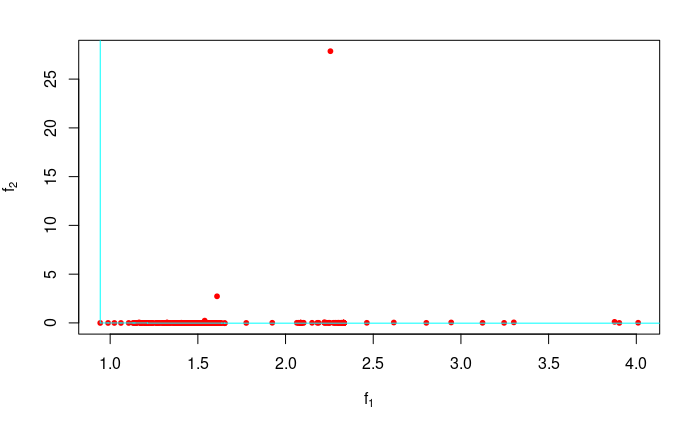

```r
plotGPareto(res)
```

```r
# Format into dataframe for easier plotting
GPar.front = data.frame(pka1 = res$par[,1], pka2 = res$par[,2], logA = res$par[,3], Na.A = res$par[,4],
                        Energy.kJ.mol = res$value[,1], Flux.mol.m2s = res$value[,2])
GPar.all =  data.frame(pka1 = res$history$X[,1], pka2 = res$history$X[,2], logA = res$history$X[,3],
                       Na.A = res$history$X[,4],
                       Energy.kJ.mol = res$history$y[,1], Flux.mol.m2s = res$history$y[,2])
rm(res)
write.csv(GPar.front, file = 'GPar_fnt_pkah.csv')
write.csv(GPar.all, file = 'GPar_all_pkah.csv')
```

```r
# Initial ranges
pka1.rng = c(2, 13.5); pka2.rng = c(0, 5.5)
logA.rng = c(-2, 0.5); Na.A.rng = c(-7, 0.7)

# Since the concentration is lower, can use the data from the previous Pareto front search, but
# filtering out points and then randomly sampling up to the required number
design.start = read.csv(file = 'GPar_all_pkah.csv')
# Set the budget as the number of points that will be filtered
Pareto.budget = nrow(design.start) - nrow(filter(design.start, pka2 < max(pka2.rng)))
design.start = filter(design.start, pka2 < max(pka2.rng))

# Separate into different matrices
result.start = design.start[,c('Energy.kJ.mol', 'Flux.mol.m2s')]
design.start = design.start[,c('pka1', 'pka2', 'logA', 'Na.A')]

res = easyGParetoptim(fn = PCET.obj.flu.base, budget = Pareto.budget,
                      lower = c(min(pka1.rng), min(pka2.rng), min(logA.rng), min(Na.A.rng)),
                      upper = c(max(pka1.rng), max(pka2.rng), max(logA.rng), max(Na.A.rng)),
                      par = as.matrix(design.start), value = as.matrix(result.start), ncores = 2)
```

```
----------------------------
Starting optimization with :
 The criterion SMS
 The solver pso
----------------------------
Ite / Crit / New x / New y
No refPoint provided,  2.21 0.995 used
1   /   -1.53   /   13.5    5.5 -1.76   -7  /   1.56    -0.00398
2   /   -1.1    /   13.5    5.5 -1.4    -2.34   /   1.42    -0.00514
3   /   -1.15   /   13.5    5.5 -1.69   -4.95   /   1.41    -0.00508
4   /   -0.884  /   13.5    5.5 -1.67   -0.461  /   1.36    -0.00508
5   /   -0.868  /   12.1    5.5 -1.67   -3.47   /   1.4 -0.00509
6   /   -0.722  /   10.5    5.5 -1.73   -2.5    /   1.47    -0.00482
7   /   -0.678  /   13.5    5.5 -1.78   0.7 /   3.33    -0.00162
8   /   -0.707  /   12.4    5.5 -1.65   -1.34   /   1.39    -0.00509
```

[output cut: 85 more lines]

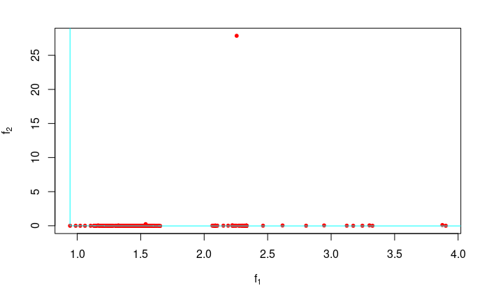

```r
plotGPareto(res)
```

```r
# Format into dataframe for easier plotting
GPar.front = data.frame(pka1 = res$par[,1], pka2 = res$par[,2], logA = res$par[,3], Na.A = res$par[,4],
                        Energy.kJ.mol = res$value[,1], Flux.mol.m2s = res$value[,2])
GPar.all =  data.frame(pka1 = res$history$X[,1], pka2 = res$history$X[,2], logA = res$history$X[,3],
                       Na.A = res$history$X[,4],
                       Energy.kJ.mol = res$history$y[,1], Flux.mol.m2s = res$history$y[,2])
rm(res)
write.csv(GPar.front, file = 'GPar_fnt_pkaM.csv')
write.csv(GPar.all, file = 'GPar_all_pkaM.csv')
```

```r
# Initial ranges
pka1.rng = c(2, 13.5); pka2.rng = c(0, 3.75)
logA.rng = c(-2, 0.5); Na.A.rng = c(-7, 0.7)

# Since the concentration is lower, can use the data from the previous Pareto front search, but
# filtering out points and then randomly sampling up to the required number
design.start = read.csv(file = 'GPar_all_pkaM.csv')
# Shorten the budget by the number of points that will be removed
Pareto.budget = nrow(design.start) - nrow(filter(design.start, pka2 < max(pka2.rng)))
design.start = filter(design.start, pka2 < max(pka2.rng))

# Separate into different matrices
result.start = design.start[,c('Energy.kJ.mol', 'Flux.mol.m2s')]
design.start = design.start[,c('pka1', 'pka2', 'logA', 'Na.A')]

res = easyGParetoptim(fn = PCET.obj.flu.base, budget = Pareto.budget,
                      lower = c(min(pka1.rng), min(pka2.rng), min(logA.rng), min(Na.A.rng)),
                      upper = c(max(pka1.rng), max(pka2.rng), max(logA.rng), max(Na.A.rng)),
                      par = as.matrix(design.start), value = as.matrix(result.start), ncores = 2)
```

```
----------------------------
Starting optimization with :
 The criterion SMS
 The solver pso
----------------------------
Ite / Crit / New x / New y
No refPoint provided,  2.21 0.994 used
1   /   -1.14   /   13.5    3.75    -1.58   -7  /   1.39    -0.0051
2   /   -0.746  /   13.5    3.75    0.5 -7  /   1.65    -0.0308
refPoint changed,  2.65 0.994 used
3   /   -1.21   /   12.2    3.75    -1.63   -2.54   /   1.39    -0.00509
4   /   -1.67   /   11.1    3.75    -1.66   -7  /   1.4 -0.00509
5   /   -1.11   /   13.5    3.75    -1.65   -1.75   /   1.39    -0.00509
6   /   -1.3    /   7.86    3.75    -1.54   -7  /   1.3 -0.00531
7   /   -1.03   /   9.96    3.75    -1.72   -4.19   /   1.45    -0.00495
```

[output cut: 130 more lines]

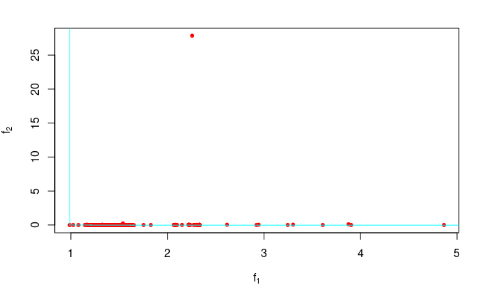

```r
plotGPareto(res)
```

```r
# Format into dataframe for easier plotting
GPar.front = data.frame(pka1 = res$par[,1], pka2 = res$par[,2], logA = res$par[,3], Na.A = res$par[,4],
                        Energy.kJ.mol = res$value[,1], Flux.mol.m2s = res$value[,2])
GPar.all =  data.frame(pka1 = res$history$X[,1], pka2 = res$history$X[,2], logA = res$history$X[,3],
                       Na.A = res$history$X[,4],
                       Energy.kJ.mol = res$history$y[,1], Flux.mol.m2s = res$history$y[,2])
rm(res)
write.csv(GPar.front, file = 'GPar_fnt_pkal.csv')
write.csv(GPar.all, file = 'GPar_all_pkal.csv')
```

```r
# Initial ranges
pka1.rng = c(2, 13.5); pka2.rng = c(0, 1)
logA.rng = c(-2, 0.5); Na.A.rng = c(-7, 0.7)

# Since the concentration is lower, can use the data from the previous Pareto front search, but
# filtering out points and then randomly sampling up to the required number
design.start = read.csv(file = 'GPar_all_pkal.csv')
# Shorten the budget by the number of points that will be removed
Pareto.budget = nrow(design.start) - nrow(filter(design.start, pka2 < max(pka2.rng)))
design.start = filter(design.start, pka2 < max(pka2.rng))

# Separate into different matrices
result.start = design.start[,c('Energy.kJ.mol', 'Flux.mol.m2s')]
design.start = design.start[,c('pka1', 'pka2', 'logA', 'Na.A')]

res = easyGParetoptim(fn = PCET.obj.flu.base, budget = Pareto.budget,
                      lower = c(min(pka1.rng), min(pka2.rng), min(logA.rng), min(Na.A.rng)),
                      upper = c(max(pka1.rng), max(pka2.rng), max(logA.rng), max(Na.A.rng)),
                      par = as.matrix(design.start), value = as.matrix(result.start), ncores = 2)
```

```
----------------------------
Starting optimization with :
 The criterion SMS
 The solver pso
----------------------------
Ite / Crit / New x / New y
No refPoint provided,  2.61 1.05 used
1   /   -2.85   /   10.5    1   -2  -5.65   /   2.33    0.00993
2   /   -1.63   /   13.5    1   -1.79   -0.715  /   3.5 -0.00178
3   /   -1.79   /   13.5    1   -1.7    -7  /   1.42    -0.00507
4   /   -1.71   /   13.5    1   -1.72   -4.97   /   1.44    -0.005
5   /   -1.6    /   7.83    1   -1.69   -7  /   1.36    -0.00417
6   /   -1.58   /   11.3    1   -1.72   -3.76   /   1.44    -0.00499
7   /   -1.35   /   11.3    1   -1.65   -7  /   1.4 -0.00509
8   /   -1.25   /   13.5    1   -2  -5.81   /   2.33    0.00993
```

[output cut: 224 more lines]

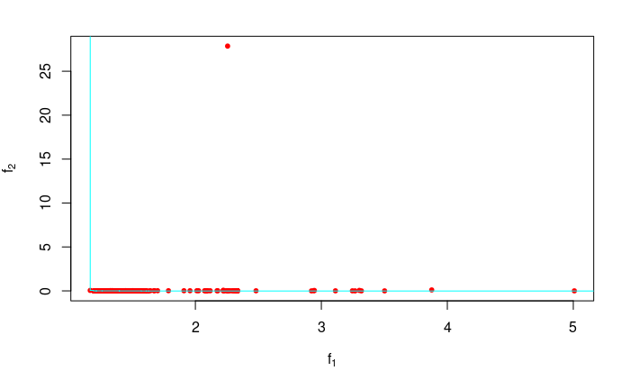

```r
plotGPareto(res)
```

```r
# Format into dataframe for easier plotting
GPar.front = data.frame(pka1 = res$par[,1], pka2 = res$par[,2], logA = res$par[,3], Na.A = res$par[,4],
                        Energy.kJ.mol = res$value[,1], Flux.mol.m2s = res$value[,2])
GPar.all =  data.frame(pka1 = res$history$X[,1], pka2 = res$history$X[,2], logA = res$history$X[,3],
                       Na.A = res$history$X[,4],
                       Energy.kJ.mol = res$history$y[,1], Flux.mol.m2s = res$history$y[,2])
rm(res)
write.csv(GPar.front, file = 'GPar_fnt_pkaL.csv')
write.csv(GPar.all, file = 'GPar_all_pkaL.csv')
```

# Comparisons

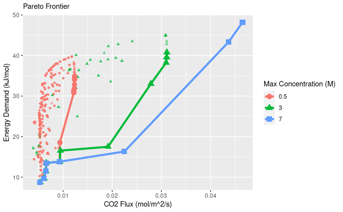

```r
GPar.front.Qlst = read.csv(file = 'GPar_fnt_Qlst.csv')
# GPar.front.Qlow = read.csv(file = 'GPar_fnt_Qlow.csv')
GPar.front.Qmid = read.csv(file = 'GPar_fnt_Qmid.csv')
# GPar.front.Qhig = read.csv(file = 'GPar_fnt_Qhig.csv')
GPar.front.Qhst = read.csv(file = 'GPar_fnt_Qhst.csv')
GPar.front.pkaL = read.csv(file = 'GPar_fnt_pkaL.csv')
# GPar.front.pkal = read.csv(file = 'GPar_fnt_pkal.csv')
GPar.front.pkaM = read.csv(file = 'GPar_fnt_pkaM.csv')
# GPar.front.pkah = read.csv(file = 'GPar_fnt_pkah.csv')
GPar.front.pkaH = read.csv(file = 'GPar_fnt_pkaH.csv')

# Label concentrations
GPar.front.Qlst$mConc = 0.5
# GPar.front.Qlow$mConc = 1
GPar.front.Qmid$mConc = 3
# GPar.front.Qhig$mConc = 5
GPar.front.Qhst$mConc = 7

# Label differences
GPar.front.pkaL$pkaDif = 1
# GPar.front.pkal$pkaDif = 3.75
GPar.front.pkaM$pkaDif = 5.5
# GPar.front.pkah$pkaDif = 7.25
GPar.front.pkaH$pkaDif = 9

# Combine the fronts
# GPar.front.con = rbind(GPar.front.Qlst, GPar.front.Qlow, GPar.front.Qmid, GPar.front.Qhig, GPar.front.Qhst)
# GPar.front.pKa = rbind(GPar.front.pkaL, GPar.front.pkal, GPar.front.pkaM, GPar.front.pkah, GPar.front.pkaH)
# rm(GPar.front.Qlst, GPar.front.Qlow, GPar.front.Qmid, GPar.front.Qhig, GPar.front.Qhst,
#    GPar.front.pkaL, GPar.front.pkal, GPar.front.pkaM, GPar.front.pkah, GPar.front.pkaH)
GPar.front.con = rbind(GPar.front.Qlst, GPar.front.Qmid, GPar.front.Qhst)
GPar.front.pKa = rbind(GPar.front.pkaL, GPar.front.pkaM, GPar.front.pkaH)
rm(GPar.front.Qlst, GPar.front.Qmid, GPar.front.Qhst,
   GPar.front.pkaL, GPar.front.pkaM, GPar.front.pkaH)

# Flip the flux sign back
GPar.front.con$Flux.mol.m2s = -GPar.front.con$Flux.mol.m2s
GPar.front.pKa$Flux.mol.m2s = -GPar.front.pKa$Flux.mol.m2s
# Non-log energy units
GPar.front.con$Energy.kJ.mol = 10^GPar.front.con$Energy.kJ.mol
GPar.front.pKa$Energy.kJ.mol = 10^GPar.front.pKa$Energy.kJ.mol

# Repeat for the full datasets
GPar.Qlst = read.csv(file = 'GPar_all_Qlst.csv')
# GPar.Qlow = read.csv(file = 'GPar_all_Qlow.csv')
GPar.Qmid = read.csv(file = 'GPar_all_Qmid.csv')
# GPar.Qhig = read.csv(file = 'GPar_all_Qhig.csv')
GPar.Qhst = read.csv(file = 'GPar_all_Qhst.csv')
GPar.pkaL = read.csv(file = 'GPar_all_pkaL.csv')
# GPar.pkal = read.csv(file = 'GPar_all_pkal.csv')
GPar.pkaM = read.csv(file = 'GPar_all_pkaM.csv')
# GPar.pkah = read.csv(file = 'GPar_all_pkah.csv')
GPar.pkaH = read.csv(file = 'GPar_all_pkaH.csv')

# Combine the fronts
# GPar.con = rbind(GPar.Qlst, GPar.Qlow, GPar.Qmid, GPar.Qhig, GPar.Qhst)
# GPar.pKa = rbind(GPar.pkaL, GPar.pkal, GPar.pkaM, GPar.pkah, GPar.pkaH)
# rm(GPar.Qlst, GPar.Qlow, GPar.Qmid, GPar.Qhig, GPar.Qhst,
#    GPar.pkaL, GPar.pkal, GPar.pkaM, GPar.pkah, GPar.pkaH)
GPar.con = rbind(GPar.Qlst, GPar.Qmid, GPar.Qhst)
GPar.pKa = rbind(GPar.pkaL, GPar.pkaM, GPar.pkaH)
rm(GPar.Qlst, GPar.Qmid, GPar.Qhst,
   GPar.pkaL, GPar.pkaM, GPar.pkaH)

# Flip the flux sign back
GPar.con$Flux.mol.m2s = -GPar.con$Flux.mol.m2s
GPar.pKa$Flux.mol.m2s = -GPar.pKa$Flux.mol.m2s
# Adjust the energy back to non-log units
GPar.con$Energy.kJ.mol = 10^GPar.con$Energy.kJ.mol
GPar.pKa$Energy.kJ.mol = 10^GPar.pKa$Energy.kJ.mol

# Label concentration and pKa differences dynamically, not based on which dataset it was generated from
GPar.con$mConc = 7
# GPar.con$mConc[GPar.con$logA <= 0.7] = 5
GPar.con$mConc[GPar.con$logA <= 0.5] = 3
# GPar.con$mConc[GPar.con$logA <= 0.0] = 1
GPar.con$mConc[GPar.con$logA <= -0.3] = 0.5

# Label differences
GPar.pKa$pkaDif = 9
# GPar.pKa$pkaDif[GPar.pKa$pka2 <= 7.25] = 7.25
GPar.pKa$pkaDif[GPar.pKa$pka2 <= 5.50] = 5.5
# GPar.pKa$pkaDif[GPar.pKa$pka2 <= 3.75] = 3.75
GPar.pKa$pkaDif[GPar.pKa$pka2 <= 1.00] = 1

sz = 1.5
ggplot() +
  geom_point(filter(GPar.con, Flux.mol.m2s > 0, Energy.kJ.mol < 100),
             mapping = aes(y = Energy.kJ.mol, x = Flux.mol.m2s,
                           color = as.factor(mConc), shape = as.factor(mConc)),
             size = sz, alpha = 0.5) +
  geom_line(filter(GPar.front.con, Flux.mol.m2s > 0, Energy.kJ.mol < 100),
            mapping = aes(y = Energy.kJ.mol, x = Flux.mol.m2s, color = as.factor(mConc)),
            size = sz) +
  geom_point(filter(GPar.front.con, Flux.mol.m2s > 0, Energy.kJ.mol < 100),
             mapping = aes(y = Energy.kJ.mol, x = Flux.mol.m2s,
                           color = as.factor(mConc), shape = as.factor(mConc)),
             size = sz+2) +
  labs(x = 'CO2 Flux (mol/m^2/s)', y = 'Energy Demand (kJ/mol)', subtitle = 'Pareto Frontier',
       color = 'Max Concentration (M)', shape = 'Max Concentration (M)')
```

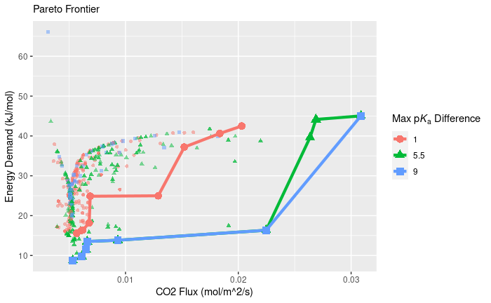

```r
ggplot() +
  geom_point(filter(GPar.pKa, Flux.mol.m2s > 0, Energy.kJ.mol < 100),
             mapping = aes(y = Energy.kJ.mol, x = Flux.mol.m2s,
                           color = as.factor(pkaDif), shape = as.factor(pkaDif)),
             size = sz, alpha = 0.5) +
  geom_line(filter(GPar.front.pKa, Flux.mol.m2s > 0, Energy.kJ.mol < 100),
            mapping = aes(y = Energy.kJ.mol, x = Flux.mol.m2s, color = as.factor(pkaDif)),
            size = sz) +
  geom_point(filter(GPar.front.pKa, Flux.mol.m2s > 0, Energy.kJ.mol < 100),
             mapping = aes(y = Energy.kJ.mol, x = Flux.mol.m2s,
                           color = as.factor(pkaDif), shape = as.factor(pkaDif)),
             size = sz+2) +
  labs(x = 'CO2 Flux (mol/m^2/s)', y = 'Energy Demand (kJ/mol)', subtitle = 'Pareto Frontier',
       color = expression('Max p'*italic(K)['a']*' Difference'),
       shape = expression('Max p'*italic(K)['a']*' Difference'))
```

```r
write.csv(GPar.front.con, 'FrontShift_conc_fnt.csv')
write.csv(GPar.front.pKa, 'FrontShift_Dpka_fnt.csv')

write.csv(GPar.con, 'FrontShift_conc_all.csv')
write.csv(GPar.pKa, 'FrontShift_Dpka_all.csv')
```

Plots of the lowest, middle, and higest show rough trends with concentration gradually shifting the Pareto front towards high fluxes without substantial changes to the energy demands.